# Lab 6

# Part 1

## A Linear

```python
import pandas as pd
import numpy as np
from sklearn.pipeline import Pipeline
from sklearn.preprocessing import StandardScaler, OneHotEncoder, PolynomialFeatures
from sklearn.linear_model import LinearRegression, Ridge, Lasso, ElasticNet
from sklearn.model_selection import train_test_split
from sklearn.metrics import r2_score
from sklearn.model_selection import cross_val_score
import pandas as pd
from sklearn.pipeline import make_pipeline
from sklearn.compose import ColumnTransformer
pd.options.display.float_format = '{:.2f}'.format
```

```python
df = pd.read_csv("/Users/kellogg/Downloads/Cal Poly 5th Year/Machine-Learning-Class-Git/Lab 6/Hitters.csv")
```

```python
df_clean = df.dropna()
df_clean
```

|  | AtBat | Hits | HmRun | Runs | RBI | Walks | Years | CAtBat | CHits | CHmRun | CRuns | CRBI | CWalks | League | Division | PutOuts | Assists | Errors | Salary | NewLeague |
| --- | --- | --- | --- | --- | --- | --- | --- | --- | --- | --- | --- | --- | --- | --- | --- | --- | --- | --- | --- | --- |
| 1 | 315 | 81 | 7 | 24 | 38 | 39 | 14 | 3449 | 835 | 69 | 321 | 414 | 375 | N | W | 632 | 43 | 10 | 475.00 | N |
| 2 | 479 | 130 | 18 | 66 | 72 | 76 | 3 | 1624 | 457 | 63 | 224 | 266 | 263 | A | W | 880 | 82 | 14 | 480.00 | A |
| 3 | 496 | 141 | 20 | 65 | 78 | 37 | 11 | 5628 | 1575 | 225 | 828 | 838 | 354 | N | E | 200 | 11 | 3 | 500.00 | N |
| 4 | 321 | 87 | 10 | 39 | 42 | 30 | 2 | 396 | 101 | 12 | 48 | 46 | 33 | N | E | 805 | 40 | 4 | 91.50 | N |
| 5 | 594 | 169 | 4 | 74 | 51 | 35 | 11 | 4408 | 1133 | 19 | 501 | 336 | 194 | A | W | 282 | 421 | 25 | 750.00 | A |
| ... | ... | ... | ... | ... | ... | ... | ... | ... | ... | ... | ... | ... | ... | ... | ... | ... | ... | ... | ... | ... |
| 317 | 497 | 127 | 7 | 65 | 48 | 37 | 5 | 2703 | 806 | 32 | 379 | 311 | 138 | N | E | 325 | 9 | 3 | 700.00 | N |
| 318 | 492 | 136 | 5 | 76 | 50 | 94 | 12 | 5511 | 1511 | 39 | 897 | 451 | 875 | A | E | 313 | 381 | 20 | 875.00 | A |
| 319 | 475 | 126 | 3 | 61 | 43 | 52 | 6 | 1700 | 433 | 7 | 217 | 93 | 146 | A | W | 37 | 113 | 7 | 385.00 | A |
| 320 | 573 | 144 | 9 | 85 | 60 | 78 | 8 | 3198 | 857 | 97 | 470 | 420 | 332 | A | E | 1314 | 131 | 12 | 960.00 | A |
| 321 | 631 | 170 | 9 | 77 | 44 | 31 | 11 | 4908 | 1457 | 30 | 775 | 357 | 249 | A | W | 408 | 4 | 3 | 1000.00 | A |

263 rows × 20 columns

```python
X = df_clean.drop(columns=['Salary'])
y = df_clean['Salary']

X_test, X_train, y_test, y_train = train_test_split(X, y, train_size=0.8, random_state=321)
```

```python
ct = ColumnTransformer(
  [
    ("dummify", OneHotEncoder(sparse_output = False), ["League", "Division", "NewLeague"]),
    ("standardize", StandardScaler(), ["AtBat", "Hits", "HmRun", "Runs", "RBI", "Walks", "Years", "CAtBat", "CHits", "CHmRun", "CRuns", "CRBI", "CWalks", "PutOuts", "Assists", "Errors"])
  ],
  remainder = "passthrough"
)

lr_pipeline = Pipeline(
  [("preprocessing", ct),
  ("linear_regression", LinearRegression())]
)

lr_pipeline

lr_pipeline_fitted = lr_pipeline.fit(X_train, y_train)

y_preds = lr_pipeline_fitted.predict(X_test)

from sklearn.metrics import mean_squared_error

mse1 = mean_squared_error(y_test, y_preds)
mse1
```

```
200833.8202038817
```

```python
model_lr = lr_pipeline.named_steps["linear_regression"]
feature_names = lr_pipeline[:-1].get_feature_names_out()
coefficients = model_lr.coef_
lr_coef_df = pd.DataFrame({
    'predictor': feature_names,
    'coefficient': coefficients
})
lr_coef_df = lr_coef_df.sort_values(by='coefficient', ascending=False)

lr_coef_df
```

|  | predictor | coefficient |
| --- | --- | --- |
| 14 | standardize__CHits | 750.54 |
| 15 | standardize__CHmRun | 208.76 |
| 10 | standardize__RBI | 189.42 |
| 20 | standardize__Assists | 180.81 |
| 2 | dummify__Division_E | 112.85 |
| 19 | standardize__PutOuts | 95.87 |
| 11 | standardize__Walks | 93.72 |
| 16 | standardize__CRuns | 59.03 |
| 9 | standardize__Runs | 46.30 |
| 1 | dummify__League_N | 40.22 |
| 7 | standardize__Hits | 26.18 |
| 5 | dummify__NewLeague_N | 21.56 |
| 4 | dummify__NewLeague_A | -21.56 |
| 0 | dummify__League_A | -40.22 |
| 18 | standardize__CWalks | -75.96 |
| 8 | standardize__HmRun | -77.21 |
| 3 | dummify__Division_W | -112.85 |
| 17 | standardize__CRBI | -190.49 |
| 21 | standardize__Errors | -208.30 |
| 13 | standardize__CAtBat | -253.57 |
| 12 | standardize__Years | -292.73 |
| 6 | standardize__AtBat | -366.67 |

```python
model_lr.intercept_
```

```
np.float64(491.6523636340394)
```

The 5 most important predictors are CHits, AtBat, Years, CAtBat, and ChmRun. This means that for each additional hit througout a career we are predicting an increase in salary of 750. The -366 coefficient for AtBat indicates that for each at bat during 1986, we expect to see a drop in salary of 366. The -292 coeficient for years indicates that we see a negative correlation between numebr of years in the MLB and salary.

The reason I looked at the absolute value is becasue the higher absolute value number indicates more of an effect, regardless of if it is posative or negative.

The intercept of 491 indicates that if all preductor variables were 0, we would expect a salary of 491.

```python
scores = cross_val_score(lr_pipeline, X, y, cv = 5, scoring = 'neg_mean_squared_error')
print(f"MSE from test train split: {mse1}")
print(f"Cross Validated MSE estimate: {-scores.mean()}")
```

```
MSE from test train split: 200833.8202038817
Cross Validated MSE estimate: 121136.31031816886
```

## B Ridge

```python
ridge_pipeline = Pipeline(
  [("preprocessing", ct),
  ("ridge_regression", Ridge(alpha=1))]
)
from sklearn.model_selection import GridSearchCV

alphas = {'ridge_regression__alpha': np.array([0.001, 0.01, 0.1, 1, 10])}

gscv = GridSearchCV(ridge_pipeline, param_grid=alphas, cv = 5, scoring='r2')
gscv_fitted = gscv.fit(X, y)

df_cv_results_ = pd.DataFrame(gscv_fitted.cv_results_)

df_cv_results_
```

|  | mean_fit_time | std_fit_time | mean_score_time | std_score_time | param_ridge_regression__alpha | params | split0_test_score | split1_test_score | split2_test_score | split3_test_score | split4_test_score | mean_test_score | std_test_score | rank_test_score |
| --- | --- | --- | --- | --- | --- | --- | --- | --- | --- | --- | --- | --- | --- | --- |
| 0 | 0.00 | 0.00 | 0.00 | 0.00 | 0.00 | {'ridge_regression__alpha': 0.001} | 0.30 | 0.57 | 0.64 | -0.02 | 0.22 | 0.34 | 0.24 | 5 |
| 1 | 0.00 | 0.00 | 0.00 | 0.00 | 0.01 | {'ridge_regression__alpha': 0.01} | 0.30 | 0.57 | 0.64 | -0.02 | 0.22 | 0.34 | 0.24 | 4 |
| 2 | 0.00 | 0.00 | 0.00 | 0.00 | 0.10 | {'ridge_regression__alpha': 0.1} | 0.30 | 0.57 | 0.65 | -0.00 | 0.23 | 0.35 | 0.24 | 3 |
| 3 | 0.00 | 0.00 | 0.00 | 0.00 | 1.00 | {'ridge_regression__alpha': 1.0} | 0.30 | 0.56 | 0.65 | 0.02 | 0.25 | 0.36 | 0.23 | 2 |
| 4 | 0.00 | 0.00 | 0.00 | 0.00 | 10.00 | {'ridge_regression__alpha': 10.0} | 0.37 | 0.51 | 0.65 | 0.04 | 0.28 | 0.37 | 0.21 | 1 |

Based on our hyperparameter tuning the best value for alpha is 10

```python
ridge_pipeline.set_params(ridge_regression__alpha=10)
ridge_pipeline.fit(X_train, y_train)
```

```
Pipeline(steps=[('preprocessing',
                 ColumnTransformer(remainder='passthrough',
                                   transformers=[('dummify',
                                                  OneHotEncoder(sparse_output=False),
                                                  ['League', 'Division',
                                                   'NewLeague']),
                                                 ('standardize',
                                                  StandardScaler(),
                                                  ['AtBat', 'Hits', 'HmRun',
                                                   'Runs', 'RBI', 'Walks',
                                                   'Years', 'CAtBat', 'CHits',
                                                   'CHmRun', 'CRuns', 'CRBI',
                                                   'CWalks', 'PutOuts',
                                                   'Assists', 'Errors'])])),
                ('ridge_regression', Ridge(alpha=10))])
```

```python
model_ridge = ridge_pipeline.named_steps["ridge_regression"]
feature_names = ridge_pipeline[:-1].get_feature_names_out()
coefficients = model_ridge.coef_
ridge_coef_df = pd.DataFrame({
    'predictor': feature_names,
    'coefficient': coefficients
})
ridge_coef_df = ridge_coef_df.sort_values(by='coefficient', ascending=False)

ridge_coef_df
```

|  | predictor | coefficient |
| --- | --- | --- |
| 17 | standardize__CRBI | 91.67 |
| 16 | standardize__CRuns | 80.03 |
| 14 | standardize__CHits | 79.71 |
| 20 | standardize__Assists | 76.37 |
| 2 | dummify__Division_E | 63.01 |
| 15 | standardize__CHmRun | 57.76 |
| 19 | standardize__PutOuts | 52.30 |
| 5 | dummify__NewLeague_N | 48.37 |
| 13 | standardize__CAtBat | 36.60 |
| 10 | standardize__RBI | 31.01 |
| 1 | dummify__League_N | 28.39 |
| 18 | standardize__CWalks | 18.50 |
| 9 | standardize__Runs | 12.79 |
| 11 | standardize__Walks | 9.14 |
| 7 | standardize__Hits | -1.04 |
| 8 | standardize__HmRun | -1.05 |
| 0 | dummify__League_A | -28.39 |
| 4 | dummify__NewLeague_A | -48.37 |
| 3 | dummify__Division_W | -63.01 |
| 21 | standardize__Errors | -95.62 |
| 6 | standardize__AtBat | -97.11 |
| 12 | standardize__Years | -111.29 |

The 5 most important predictors are Years, CRBI, AtBat, Error, and CRuns. We are predicting that each additional year leads to a -111 in predicted salary. The AtBat and Errors coefficients are -97 and -95. This means we are predicting lower values of salary with each increase in AtBat or Error.

```python
ridge_pipeline

ridge_pipeline_fitted = ridge_pipeline.fit(X_train, y_train)

y_preds = ridge_pipeline_fitted.predict(X_test)


mse2 = mean_squared_error(y_test, y_preds)
mse2
scores = cross_val_score(ridge_pipeline, X, y, cv = 5, scoring = 'neg_mean_squared_error')
print(f"MSE from test train split: {mse2}")
print(f"Cross Validated MSE estimate: {-scores.mean()}")
```

```
MSE from test train split: 167191.33420723715
Cross Validated MSE estimate: 119348.98477570356
```

## C Lasso

```python
lasso_pipeline = Pipeline(
  [("preprocessing", ct),
  ("lasso_regression", Lasso(alpha=1))]
)

alphas = {'lasso_regression__alpha': np.array([100, 10, 1, 0.1, 0.01])}

gscv = GridSearchCV(lasso_pipeline, param_grid=alphas, cv = 5, scoring='r2')
gscv_fitted = gscv.fit(X, y)

df_cv_results_ = pd.DataFrame(gscv_fitted.cv_results_)

df_cv_results_
```

|  | mean_fit_time | std_fit_time | mean_score_time | std_score_time | param_lasso_regression__alpha | params | split0_test_score | split1_test_score | split2_test_score | split3_test_score | split4_test_score | mean_test_score | std_test_score | rank_test_score |
| --- | --- | --- | --- | --- | --- | --- | --- | --- | --- | --- | --- | --- | --- | --- |
| 0 | 0.00 | 0.00 | 0.00 | 0.00 | 100.00 | {'lasso_regression__alpha': 100.0} | 0.50 | 0.21 | 0.35 | 0.10 | 0.34 | 0.30 | 0.13 | 5 |
| 1 | 0.00 | 0.00 | 0.00 | 0.00 | 10.00 | {'lasso_regression__alpha': 10.0} | 0.45 | 0.46 | 0.60 | 0.04 | 0.29 | 0.37 | 0.19 | 1 |
| 2 | 0.01 | 0.00 | 0.00 | 0.00 | 1.00 | {'lasso_regression__alpha': 1.0} | 0.31 | 0.55 | 0.65 | 0.01 | 0.25 | 0.35 | 0.23 | 2 |
| 3 | 0.01 | 0.00 | 0.00 | 0.00 | 0.10 | {'lasso_regression__alpha': 0.1} | 0.30 | 0.57 | 0.65 | -0.01 | 0.23 | 0.35 | 0.24 | 3 |
| 4 | 0.01 | 0.00 | 0.00 | 0.00 | 0.01 | {'lasso_regression__alpha': 0.01} | 0.30 | 0.57 | 0.64 | -0.02 | 0.22 | 0.34 | 0.24 | 4 |

Based on our hyperparameter tuning the best value for alpha is 10

```python
lasso_pipeline.set_params(lasso_regression__alpha=10)
lasso_pipeline.fit(X_train, y_train)
```

```
Pipeline(steps=[('preprocessing',
                 ColumnTransformer(remainder='passthrough',
                                   transformers=[('dummify',
                                                  OneHotEncoder(sparse_output=False),
                                                  ['League', 'Division',
                                                   'NewLeague']),
                                                 ('standardize',
                                                  StandardScaler(),
                                                  ['AtBat', 'Hits', 'HmRun',
                                                   'Runs', 'RBI', 'Walks',
                                                   'Years', 'CAtBat', 'CHits',
                                                   'CHmRun', 'CRuns', 'CRBI',
                                                   'CWalks', 'PutOuts',
                                                   'Assists', 'Errors'])])),
                ('lasso_regression', Lasso(alpha=10))])
```

```python
model_lasso = lasso_pipeline.named_steps["lasso_regression"]
feature_names = lasso_pipeline[:-1].get_feature_names_out()
coefficients = model_lasso.coef_
lasso_coef_df = pd.DataFrame({
    'predictor': feature_names,
    'coefficient': coefficients
})
lasso_coef_df = lasso_coef_df.sort_values(by='coefficient', ascending=False)

lasso_coef_df
```

|  | predictor | coefficient |
| --- | --- | --- |
| 17 | standardize__CRBI | 184.44 |
| 14 | standardize__CHits | 162.89 |
| 2 | dummify__Division_E | 153.14 |
| 16 | standardize__CRuns | 108.51 |
| 20 | standardize__Assists | 97.87 |
| 19 | standardize__PutOuts | 71.75 |
| 10 | standardize__RBI | 35.24 |
| 5 | dummify__NewLeague_N | 0.00 |
| 0 | dummify__League_A | -0.00 |
| 13 | standardize__CAtBat | 0.00 |
| 18 | standardize__CWalks | 0.00 |
| 15 | standardize__CHmRun | 0.00 |
| 11 | standardize__Walks | 0.00 |
| 1 | dummify__League_N | 0.00 |
| 9 | standardize__Runs | 0.00 |
| 8 | standardize__HmRun | 0.00 |
| 7 | standardize__Hits | 0.00 |
| 3 | dummify__Division_W | -0.00 |
| 4 | dummify__NewLeague_A | -109.55 |
| 6 | standardize__AtBat | -124.60 |
| 21 | standardize__Errors | -137.16 |
| 12 | standardize__Years | -214.03 |

```python
lasso_pipeline

lasso_pipeline_fitted = lasso_pipeline.fit(X_train, y_train)

y_preds = lasso_pipeline_fitted.predict(X_test)

mse3 = mean_squared_error(y_test, y_preds)
mse3
scores = cross_val_score(lasso_pipeline, X, y, cv = 5, scoring = 'neg_mean_squared_error')
print(f"MSE from test train split: {mse3}")
print(f"Cross Validated MSE estimate: {-scores.mean()}")
```

```
MSE from test train split: 186048.63962840792
Cross Validated MSE estimate: 121828.14133338635
```

## D Elastic

```python
elastic_pipeline = Pipeline(
  [("preprocessing", ct),
  ("elastic_net", ElasticNet(alpha=1, l1_ratio=0.5))]
)

param_grid = {
    "elastic_net__alpha": [1, 10, 100],
    "elastic_net__l1_ratio": np.arange(0.0, 1.2, 0.2),
}

gscv = GridSearchCV(elastic_pipeline, param_grid, cv = 5, scoring='r2')
gscv_fitted = gscv.fit(X, y)

df_cv_results_ = pd.DataFrame(gscv_fitted.cv_results_)

df_cv_results_
```

|  | mean_fit_time | std_fit_time | mean_score_time | std_score_time | param_elastic_net__alpha | param_elastic_net__l1_ratio | params | split0_test_score | split1_test_score | split2_test_score | split3_test_score | split4_test_score | mean_test_score | std_test_score | rank_test_score |
| --- | --- | --- | --- | --- | --- | --- | --- | --- | --- | --- | --- | --- | --- | --- | --- |
| 0 | 0.01 | 0.00 | 0.00 | 0.00 | 1 | 0.00 | {'elastic_net__alpha': 1, 'elastic_net__l1_rat... | 0.54 | 0.42 | 0.54 | 0.08 | 0.36 | 0.39 | 0.17 | 3 |
| 1 | 0.00 | 0.00 | 0.00 | 0.00 | 1 | 0.20 | {'elastic_net__alpha': 1, 'elastic_net__l1_rat... | 0.53 | 0.42 | 0.55 | 0.07 | 0.35 | 0.39 | 0.17 | 1 |
| 2 | 0.00 | 0.00 | 0.00 | 0.00 | 1 | 0.40 | {'elastic_net__alpha': 1, 'elastic_net__l1_rat... | 0.52 | 0.43 | 0.57 | 0.07 | 0.35 | 0.39 | 0.18 | 2 |
| 3 | 0.00 | 0.00 | 0.00 | 0.00 | 1 | 0.60 | {'elastic_net__alpha': 1, 'elastic_net__l1_rat... | 0.50 | 0.45 | 0.59 | 0.06 | 0.33 | 0.38 | 0.18 | 4 |
| 4 | 0.00 | 0.00 | 0.00 | 0.00 | 1 | 0.80 | {'elastic_net__alpha': 1, 'elastic_net__l1_rat... | 0.46 | 0.46 | 0.61 | 0.05 | 0.31 | 0.38 | 0.19 | 5 |
| 5 | 0.01 | 0.00 | 0.00 | 0.00 | 1 | 1.00 | {'elastic_net__alpha': 1, 'elastic_net__l1_rat... | 0.31 | 0.55 | 0.65 | 0.01 | 0.25 | 0.35 | 0.23 | 8 |
| 6 | 0.01 | 0.00 | 0.00 | 0.00 | 10 | 0.00 | {'elastic_net__alpha': 10, 'elastic_net__l1_ra... | 0.39 | 0.21 | 0.29 | 0.12 | 0.26 | 0.26 | 0.09 | 13 |
| 7 | 0.00 | 0.00 | 0.00 | 0.00 | 10 | 0.20 | {'elastic_net__alpha': 10, 'elastic_net__l1_ra... | 0.43 | 0.24 | 0.32 | 0.13 | 0.28 | 0.28 | 0.10 | 12 |
| 8 | 0.00 | 0.00 | 0.00 | 0.00 | 10 | 0.40 | {'elastic_net__alpha': 10, 'elastic_net__l1_ra... | 0.47 | 0.27 | 0.36 | 0.13 | 0.31 | 0.31 | 0.11 | 10 |
| 9 | 0.00 | 0.00 | 0.00 | 0.00 | 10 | 0.60 | {'elastic_net__alpha': 10, 'elastic_net__l1_ra... | 0.52 | 0.31 | 0.41 | 0.13 | 0.34 | 0.34 | 0.13 | 9 |
| 10 | 0.00 | 0.00 | 0.00 | 0.00 | 10 | 0.80 | {'elastic_net__alpha': 10, 'elastic_net__l1_ra... | 0.55 | 0.36 | 0.47 | 0.11 | 0.36 | 0.37 | 0.15 | 6 |
| 11 | 0.00 | 0.00 | 0.00 | 0.00 | 10 | 1.00 | {'elastic_net__alpha': 10, 'elastic_net__l1_ra... | 0.45 | 0.46 | 0.60 | 0.04 | 0.29 | 0.37 | 0.19 | 7 |
| 12 | 0.01 | 0.00 | 0.00 | 0.00 | 100 | 0.00 | {'elastic_net__alpha': 100, 'elastic_net__l1_r... | 0.00 | -0.04 | 0.05 | 0.03 | 0.04 | 0.02 | 0.03 | 18 |
| 13 | 0.00 | 0.00 | 0.00 | 0.00 | 100 | 0.20 | {'elastic_net__alpha': 100, 'elastic_net__l1_r... | 0.01 | -0.03 | 0.06 | 0.03 | 0.05 | 0.02 | 0.03 | 17 |
| 14 | 0.00 | 0.00 | 0.00 | 0.00 | 100 | 0.40 | {'elastic_net__alpha': 100, 'elastic_net__l1_r... | 0.03 | -0.03 | 0.07 | 0.04 | 0.06 | 0.03 | 0.03 | 16 |
| 15 | 0.00 | 0.00 | 0.00 | 0.00 | 100 | 0.60 | {'elastic_net__alpha': 100, 'elastic_net__l1_r... | 0.06 | -0.01 | 0.08 | 0.05 | 0.07 | 0.05 | 0.03 | 15 |
| 16 | 0.00 | 0.00 | 0.00 | 0.00 | 100 | 0.80 | {'elastic_net__alpha': 100, 'elastic_net__l1_r... | 0.13 | 0.02 | 0.12 | 0.07 | 0.12 | 0.09 | 0.04 | 14 |
| 17 | 0.00 | 0.00 | 0.00 | 0.00 | 100 | 1.00 | {'elastic_net__alpha': 100, 'elastic_net__l1_r... | 0.50 | 0.21 | 0.35 | 0.10 | 0.34 | 0.30 | 0.13 | 11 |

Based on our hyperparameter tuning the best value for alpha is 1, and best l1 ratio is 0.2.

```python
elastic_pipeline.set_params(elastic_net__alpha=1, elastic_net__l1_ratio=.2)
elastic_pipeline.fit(X_train, y_train)
```

```
Pipeline(steps=[('preprocessing',
                 ColumnTransformer(remainder='passthrough',
                                   transformers=[('dummify',
                                                  OneHotEncoder(sparse_output=False),
                                                  ['League', 'Division',
                                                   'NewLeague']),
                                                 ('standardize',
                                                  StandardScaler(),
                                                  ['AtBat', 'Hits', 'HmRun',
                                                   'Runs', 'RBI', 'Walks',
                                                   'Years', 'CAtBat', 'CHits',
                                                   'CHmRun', 'CRuns', 'CRBI',
                                                   'CWalks', 'PutOuts',
                                                   'Assists', 'Errors'])])),
                ('elastic_net', ElasticNet(alpha=1, l1_ratio=0.2))])
```

```python
model_elastic = elastic_pipeline.named_steps["elastic_net"]
feature_names = elastic_pipeline[:-1].get_feature_names_out()
coefficients = model_elastic.coef_
elastic_coef_df = pd.DataFrame({
    'predictor': feature_names,
    'coefficient': coefficients
})
elastic_coef_df = elastic_coef_df.sort_values(by='coefficient', ascending=False)

elastic_coef_df
```

|  | predictor | coefficient |
| --- | --- | --- |
| 17 | standardize__CRBI | 55.50 |
| 15 | standardize__CHmRun | 48.79 |
| 16 | standardize__CRuns | 47.41 |
| 14 | standardize__CHits | 45.21 |
| 13 | standardize__CAtBat | 32.97 |
| 18 | standardize__CWalks | 31.24 |
| 2 | dummify__Division_E | 29.76 |
| 5 | dummify__NewLeague_N | 29.20 |
| 19 | standardize__PutOuts | 26.43 |
| 20 | standardize__Assists | 25.27 |
| 1 | dummify__League_N | 22.46 |
| 10 | standardize__RBI | 11.16 |
| 11 | standardize__Walks | 5.31 |
| 8 | standardize__HmRun | 2.72 |
| 9 | standardize__Runs | 1.48 |
| 7 | standardize__Hits | -1.34 |
| 12 | standardize__Years | -21.20 |
| 0 | dummify__League_A | -22.46 |
| 4 | dummify__NewLeague_A | -29.20 |
| 3 | dummify__Division_W | -29.76 |
| 6 | standardize__AtBat | -32.92 |
| 21 | standardize__Errors | -40.22 |

The 5 most important predictors are CRBI, CHmRun, CRuns, CHits, and Errors. Respectivly, the coefficients of 55, 48, 47, 45, and -40 indicate that for each 1 unit increase for the given coefficient we can expect to see the corresponding increase/decrease in predicted salary.

```python
elastic_pipeline

elastic_pipeline_fitted = elastic_pipeline.fit(X_train, y_train)

y_preds = elastic_pipeline_fitted.predict(X_test)

mse4 = mean_squared_error(y_test, y_preds)
mse4
scores = cross_val_score(elastic_pipeline, X, y, cv = 5, scoring = 'neg_mean_squared_error')
print(f"MSE from test train split: {mse4}")
print(f"Cross Validated MSE estimate: {-scores.mean()}")
```

```
MSE from test train split: 149393.46492381228
Cross Validated MSE estimate: 121500.81646251371
```

# Part 2

The 5 most important numeric variables are CRBI, Years, AtBat, CHits, and Errors. I determined this because these variables were consistently in the top 5 most important variables for the 4 differnt models.

The most important categorical variable was Division. This was evident as it consistently outpreformed the other categorical variables.

## 1 Variable Linear

```python
X_p2 = X[['CRBI']]
y = df_clean['Salary']

X_test, X_train, y_test, y_train = train_test_split(X_p2, y, train_size=0.8, random_state=321
)
```

```python
ct = ColumnTransformer(
  [("standardize", StandardScaler(), ["CRBI"])],
  remainder = "passthrough"
)

lr_pipeline = Pipeline(
  [("preprocessing", ct),
  ("linear_regression", LinearRegression())]
)

lr_pipeline

lr_pipeline_fitted = lr_pipeline.fit(X_train, y_train)

y_preds = lr_pipeline_fitted.predict(X_test)

from sklearn.metrics import mean_squared_error

mse1 = mean_squared_error(y_test, y_preds)
mse1
```

```
157334.50831103473
```

```python
model_lr = lr_pipeline.named_steps["linear_regression"]
feature_names = lr_pipeline[:-1].get_feature_names_out()
coefficients = model_lr.coef_
lr_coef_df = pd.DataFrame({
    'predictor': feature_names,
    'coefficient': coefficients
})
lr_coef_df = lr_coef_df.sort_values(by='coefficient', ascending=False)

lr_coef_df
```

|  | predictor | coefficient |
| --- | --- | --- |
| 0 | standardize__CRBI | 271.97 |

```python
model_lr.intercept_
```

```
np.float64(487.95283018867923)
```

```python
scores = cross_val_score(lr_pipeline, X_p2, y, cv = 5, scoring = 'neg_mean_squared_error')
print(f"MSE from test train split: {mse1}")
print(f"Cross Validated MSE estimate: {-scores.mean()}")
```

```
MSE from test train split: 157334.50831103473
Cross Validated MSE estimate: 142142.865462403
```

## 5 Variables Linear

```python
X_p2 = X[["CRBI", "Years", "AtBat", "CHits", "Errors"]]
y = df_clean['Salary']

X_test, X_train, y_test, y_train = train_test_split(X_p2, y, train_size=0.8, random_state=321)
```

```python
ct = ColumnTransformer(
  [("standardize", StandardScaler(), ["CRBI", "Years", "AtBat", "CHits", "Errors"])],
  remainder = "passthrough"
)

lr_pipeline = Pipeline(
  [("preprocessing", ct),
  ("linear_regression", LinearRegression())]
)

lr_pipeline

lr_pipeline_fitted = lr_pipeline.fit(X_train, y_train)

y_preds = lr_pipeline_fitted.predict(X_test)

from sklearn.metrics import mean_squared_error

mse2 = mean_squared_error(y_test, y_preds)
mse2
```

```
237021.6505199456
```

```python
model_lr = lr_pipeline.named_steps["linear_regression"]
feature_names = lr_pipeline[:-1].get_feature_names_out()
coefficients = model_lr.coef_
lr_coef_df = pd.DataFrame({
    'predictor': feature_names,
    'coefficient': coefficients
})
lr_coef_df = lr_coef_df.sort_values(by='coefficient', ascending=False)

lr_coef_df
```

|  | predictor | coefficient |
| --- | --- | --- |
| 3 | standardize__CHits | 380.87 |
| 0 | standardize__CRBI | 182.50 |
| 2 | standardize__AtBat | -117.68 |
| 4 | standardize__Errors | -118.30 |
| 1 | standardize__Years | -321.79 |

```python
model_lr.intercept_
```

```
np.float64(487.95283018867923)
```

```python
scores = cross_val_score(lr_pipeline, X_p2, y, cv = 5, scoring = 'neg_mean_squared_error')
print(f"MSE from test train split: {mse2}")
print(f"Cross Validated MSE estimate: {-scores.mean()}")
```

```
MSE from test train split: 237021.6505199456
Cross Validated MSE estimate: 130181.75974068046
```

## 5 Variables with Interaction Linear

```python
X_p2 = X[["CRBI", "Years", "AtBat", "CHits", "Errors", "Division"]]
y = df_clean['Salary']

X_test, X_train, y_test, y_train = train_test_split(X_p2, y, train_size=0.8, random_state=321)
```

```python
ct = ColumnTransformer(
  [("dummify", OneHotEncoder(sparse_output = False), ["Division"]),
    ("standardize", StandardScaler(), ["CRBI", "Years", "AtBat", "CHits", "Errors"])],
  remainder = "passthrough"
)

lr_pipeline = Pipeline(
  [("preprocessing", ct),
  ("interaction", PolynomialFeatures(interaction_only=True, include_bias=False)),
  ("linear_regression", LinearRegression())]
)

lr_pipeline

lr_pipeline_fitted = lr_pipeline.fit(X_train, y_train)

y_preds = lr_pipeline_fitted.predict(X_test)

from sklearn.metrics import mean_squared_error

mse3 = mean_squared_error(y_test, y_preds)
mse3
```

```
166199.75656466748
```

```python
model_lr = lr_pipeline.named_steps["linear_regression"]
feature_names = lr_pipeline[:-1].get_feature_names_out()
coefficients = model_lr.coef_
lr_coef_df = pd.DataFrame({
    'predictor': feature_names,
    'coefficient': coefficients
})
lr_coef_df = lr_coef_df.sort_values(by='coefficient', ascending=False)

lr_coef_df
```

|  | predictor | coefficient |
| --- | --- | --- |
| 5 | standardize__CHits | 272.49 |
| 8 | dummify__Division_E standardize__CRBI | 194.18 |
| 16 | dummify__Division_W standardize__CHits | 164.01 |
| 25 | standardize__AtBat standardize__CHits | 144.21 |
| 11 | dummify__Division_E standardize__CHits | 108.48 |
| 2 | standardize__CRBI | 107.37 |
| 15 | dummify__Division_W standardize__AtBat | 97.80 |
| 26 | standardize__AtBat standardize__Errors | 85.14 |
| 0 | dummify__Division_E | 69.44 |
| 21 | standardize__CRBI standardize__Errors | 61.97 |
| 23 | standardize__Years standardize__CHits | 31.89 |
| 24 | standardize__Years standardize__Errors | 17.13 |
| 22 | standardize__Years standardize__AtBat | 11.07 |
| 19 | standardize__CRBI standardize__AtBat | 10.68 |
| 20 | standardize__CRBI standardize__CHits | 9.45 |
| 14 | dummify__Division_W standardize__Years | 9.00 |
| 17 | dummify__Division_W standardize__Errors | 2.52 |
| 7 | dummify__Division_E dummify__Division_W | 0.00 |
| 4 | standardize__AtBat | -13.05 |
| 6 | standardize__Errors | -53.43 |
| 12 | dummify__Division_E standardize__Errors | -55.95 |
| 1 | dummify__Division_W | -69.44 |
| 27 | standardize__CHits standardize__Errors | -82.95 |
| 13 | dummify__Division_W standardize__CRBI | -86.82 |
| 18 | standardize__CRBI standardize__Years | -101.93 |
| 10 | dummify__Division_E standardize__AtBat | -110.85 |
| 3 | standardize__Years | -182.03 |
| 9 | dummify__Division_E standardize__Years | -191.03 |

```python
model_lr.intercept_
```

```
np.float64(488.53943650323816)
```

```python
scores = cross_val_score(lr_pipeline, X_p2, y, cv = 5, scoring = 'neg_mean_squared_error')
print(f"MSE from test train split: {mse3}")
print(f"Cross Validated MSE estimate: {-scores.mean()}")
```

```
MSE from test train split: 166199.75656466748
Cross Validated MSE estimate: 97531.29138427677
```

## 1 Variable Ridge

```python
X_p2 = X[["CRBI"]]
y = df_clean['Salary']
X_test, X_train, y_test, y_train = train_test_split(X_p2, y, train_size=0.8, random_state=321)
```

```python
ct = ColumnTransformer(
  [("standardize", StandardScaler(), ["CRBI"])],
  remainder = "passthrough"
)

ridge_pipeline = Pipeline(
  [("preprocessing", ct),
  ("ridge_regression", Ridge(alpha=1))]
)
from sklearn.model_selection import GridSearchCV

alphas = {'ridge_regression__alpha': np.array([0.001, 0.01, 0.1, 1, 10])}

gscv = GridSearchCV(ridge_pipeline, param_grid=alphas, cv = 5, scoring='r2')
gscv_fitted = gscv.fit(X_p2, y)

df_cv_results_ = pd.DataFrame(gscv_fitted.cv_results_)

df_cv_results_
```

|  | mean_fit_time | std_fit_time | mean_score_time | std_score_time | param_ridge_regression__alpha | params | split0_test_score | split1_test_score | split2_test_score | split3_test_score | split4_test_score | mean_test_score | std_test_score | rank_test_score |
| --- | --- | --- | --- | --- | --- | --- | --- | --- | --- | --- | --- | --- | --- | --- |
| 0 | 0.00 | 0.00 | 0.00 | 0.00 | 0.00 | {'ridge_regression__alpha': 0.001} | 0.36 | 0.30 | 0.47 | -0.03 | 0.31 | 0.28 | 0.17 | 5 |
| 1 | 0.00 | 0.00 | 0.00 | 0.00 | 0.01 | {'ridge_regression__alpha': 0.01} | 0.36 | 0.30 | 0.47 | -0.03 | 0.31 | 0.28 | 0.17 | 4 |
| 2 | 0.00 | 0.00 | 0.00 | 0.00 | 0.10 | {'ridge_regression__alpha': 0.1} | 0.36 | 0.30 | 0.47 | -0.03 | 0.31 | 0.28 | 0.17 | 3 |
| 3 | 0.00 | 0.00 | 0.00 | 0.00 | 1.00 | {'ridge_regression__alpha': 1.0} | 0.36 | 0.30 | 0.47 | -0.03 | 0.31 | 0.28 | 0.17 | 2 |
| 4 | 0.00 | 0.00 | 0.00 | 0.00 | 10.00 | {'ridge_regression__alpha': 10.0} | 0.37 | 0.29 | 0.46 | -0.01 | 0.31 | 0.28 | 0.16 | 1 |

Based on our hyperparameter tuning the best value for alpha is 10

```python
ridge_pipeline.set_params(ridge_regression__alpha=10)
ridge_pipeline.fit(X_train, y_train)
```

```
Pipeline(steps=[('preprocessing',
                 ColumnTransformer(remainder='passthrough',
                                   transformers=[('standardize',
                                                  StandardScaler(),
                                                  ['CRBI'])])),
                ('ridge_regression', Ridge(alpha=10))])
```

```python
model_ridge = ridge_pipeline.named_steps["ridge_regression"]
feature_names = ridge_pipeline[:-1].get_feature_names_out()
coefficients = model_ridge.coef_
ridge_coef_df = pd.DataFrame({
    'predictor': feature_names,
    'coefficient': coefficients
})
ridge_coef_df = ridge_coef_df.sort_values(by='coefficient', ascending=False)

ridge_coef_df
```

|  | predictor | coefficient |
| --- | --- | --- |
| 0 | standardize__CRBI | 228.80 |

```python
ridge_pipeline

ridge_pipeline_fitted = ridge_pipeline.fit(X_train, y_train)

y_preds = ridge_pipeline_fitted.predict(X_test)


mse2 = mean_squared_error(y_test, y_preds)
mse2
scores = cross_val_score(ridge_pipeline, X_p2, y, cv = 5, scoring = 'neg_mean_squared_error')
print(f"MSE from test train split: {mse2}")
print(f"Cross Validated MSE estimate: {-scores.mean()}")
```

```
MSE from test train split: 145758.55544086653
Cross Validated MSE estimate: 142096.24206102983
```

## 5 Variable Ridge

```python
X_p2 = X[["CRBI", "Years", "AtBat", "CHits", "Errors"]]
y = df_clean['Salary']
X_test, X_train, y_test, y_train = train_test_split(X_p2, y, train_size=0.8, random_state=321)
```

```python
ct = ColumnTransformer(
  [("standardize", StandardScaler(), ["CRBI", "Years", "AtBat", "CHits", "Errors"])],
  remainder = "passthrough"
)

ridge_pipeline = Pipeline(
  [("preprocessing", ct),
  ("ridge_regression", Ridge(alpha=1))]
)
from sklearn.model_selection import GridSearchCV

alphas = {'ridge_regression__alpha': np.array([0.001, 0.01, 0.1, 1, 10])}

gscv = GridSearchCV(ridge_pipeline, param_grid=alphas, cv = 5, scoring='r2')
gscv_fitted = gscv.fit(X_p2, y)

df_cv_results_ = pd.DataFrame(gscv_fitted.cv_results_)

df_cv_results_
```

|  | mean_fit_time | std_fit_time | mean_score_time | std_score_time | param_ridge_regression__alpha | params | split0_test_score | split1_test_score | split2_test_score | split3_test_score | split4_test_score | mean_test_score | std_test_score | rank_test_score |
| --- | --- | --- | --- | --- | --- | --- | --- | --- | --- | --- | --- | --- | --- | --- |
| 0 | 0.00 | 0.00 | 0.00 | 0.00 | 0.00 | {'ridge_regression__alpha': 0.001} | 0.42 | 0.42 | 0.54 | -0.04 | 0.33 | 0.33 | 0.20 | 5 |
| 1 | 0.00 | 0.00 | 0.00 | 0.00 | 0.01 | {'ridge_regression__alpha': 0.01} | 0.42 | 0.42 | 0.54 | -0.04 | 0.33 | 0.33 | 0.20 | 4 |
| 2 | 0.00 | 0.00 | 0.00 | 0.00 | 0.10 | {'ridge_regression__alpha': 0.1} | 0.42 | 0.42 | 0.54 | -0.04 | 0.33 | 0.33 | 0.20 | 3 |
| 3 | 0.00 | 0.00 | 0.00 | 0.00 | 1.00 | {'ridge_regression__alpha': 1.0} | 0.43 | 0.42 | 0.54 | -0.04 | 0.33 | 0.33 | 0.20 | 2 |
| 4 | 0.00 | 0.00 | 0.00 | 0.00 | 10.00 | {'ridge_regression__alpha': 10.0} | 0.47 | 0.40 | 0.52 | -0.01 | 0.34 | 0.34 | 0.19 | 1 |

Based on our hyperparameter tuning the best value for alpha is 10

```python
ridge_pipeline.set_params(ridge_regression__alpha=10)
ridge_pipeline.fit(X_train, y_train)
```

```
Pipeline(steps=[('preprocessing',
                 ColumnTransformer(remainder='passthrough',
                                   transformers=[('standardize',
                                                  StandardScaler(),
                                                  ['CRBI', 'Years', 'AtBat',
                                                   'CHits', 'Errors'])])),
                ('ridge_regression', Ridge(alpha=10))])
```

```python
model_ridge = ridge_pipeline.named_steps["ridge_regression"]
feature_names = ridge_pipeline[:-1].get_feature_names_out()
coefficients = model_ridge.coef_
ridge_coef_df = pd.DataFrame({
    'predictor': feature_names,
    'coefficient': coefficients
})
ridge_coef_df = ridge_coef_df.sort_values(by='coefficient', ascending=False)

ridge_coef_df
```

|  | predictor | coefficient |
| --- | --- | --- |
| 0 | standardize__CRBI | 174.78 |
| 3 | standardize__CHits | 153.75 |
| 2 | standardize__AtBat | -49.09 |
| 4 | standardize__Errors | -62.83 |
| 1 | standardize__Years | -92.82 |

```python
ridge_pipeline

ridge_pipeline_fitted = ridge_pipeline.fit(X_train, y_train)

y_preds = ridge_pipeline_fitted.predict(X_test)


mse2 = mean_squared_error(y_test, y_preds)
mse2
scores = cross_val_score(ridge_pipeline, X_p2, y, cv = 5, scoring = 'neg_mean_squared_error')
print(f"MSE from test train split: {mse2}")
print(f"Cross Validated MSE estimate: {-scores.mean()}")
```

```
MSE from test train split: 172291.04177513884
Cross Validated MSE estimate: 129253.22590389421
```

## 5 Variable Interaction Ridge

```python
X_p2 = X[["CRBI", "Years", "AtBat", "CHits", "Errors", "Division"]]
y = df_clean['Salary']
X_test, X_train, y_test, y_train = train_test_split(X_p2, y, train_size=0.8, random_state=321)
```

```python
ct = ColumnTransformer(
  [("dummify", OneHotEncoder(sparse_output = False), ["Division"]),
    ("standardize", StandardScaler(), ["CRBI", "Years", "AtBat", "CHits", "Errors"])],
  remainder = "passthrough"
)

ridge_pipeline = Pipeline(
  [("preprocessing", ct),
  ("interaction", PolynomialFeatures(interaction_only=True, include_bias=False)),
  ("ridge_regression", Ridge(alpha=1))]
)
from sklearn.model_selection import GridSearchCV

alphas = {'ridge_regression__alpha': np.array([0.001, 0.01, 0.1, 1, 10])}

gscv = GridSearchCV(ridge_pipeline, param_grid=alphas, cv = 5, scoring='r2')
gscv_fitted = gscv.fit(X_p2, y)

df_cv_results_ = pd.DataFrame(gscv_fitted.cv_results_)

df_cv_results_
```

|  | mean_fit_time | std_fit_time | mean_score_time | std_score_time | param_ridge_regression__alpha | params | split0_test_score | split1_test_score | split2_test_score | split3_test_score | split4_test_score | mean_test_score | std_test_score | rank_test_score |
| --- | --- | --- | --- | --- | --- | --- | --- | --- | --- | --- | --- | --- | --- | --- |
| 0 | 0.00 | 0.00 | 0.00 | 0.00 | 0.00 | {'ridge_regression__alpha': 0.001} | 0.31 | 0.70 | 0.76 | -0.01 | 0.56 | 0.46 | 0.28 | 5 |
| 1 | 0.00 | 0.00 | 0.00 | 0.00 | 0.01 | {'ridge_regression__alpha': 0.01} | 0.31 | 0.70 | 0.76 | -0.01 | 0.56 | 0.46 | 0.28 | 4 |
| 2 | 0.00 | 0.00 | 0.00 | 0.00 | 0.10 | {'ridge_regression__alpha': 0.1} | 0.31 | 0.70 | 0.76 | -0.01 | 0.56 | 0.47 | 0.28 | 3 |
| 3 | 0.00 | 0.00 | 0.00 | 0.00 | 1.00 | {'ridge_regression__alpha': 1.0} | 0.33 | 0.70 | 0.76 | -0.01 | 0.57 | 0.47 | 0.28 | 2 |
| 4 | 0.00 | 0.00 | 0.00 | 0.00 | 10.00 | {'ridge_regression__alpha': 10.0} | 0.38 | 0.69 | 0.73 | 0.00 | 0.57 | 0.48 | 0.27 | 1 |

Based on our hyperparameter tuning the best value for alpha is 10

```python
ridge_pipeline.set_params(ridge_regression__alpha=10)
ridge_pipeline.fit(X_train, y_train)
```

```
Pipeline(steps=[('preprocessing',
                 ColumnTransformer(remainder='passthrough',
                                   transformers=[('dummify',
                                                  OneHotEncoder(sparse_output=False),
                                                  ['Division']),
                                                 ('standardize',
                                                  StandardScaler(),
                                                  ['CRBI', 'Years', 'AtBat',
                                                   'CHits', 'Errors'])])),
                ('interaction',
                 PolynomialFeatures(include_bias=False, interaction_only=True)),
                ('ridge_regression', Ridge(alpha=10))])
```

```python
model_ridge = ridge_pipeline.named_steps["ridge_regression"]
feature_names = ridge_pipeline[:-1].get_feature_names_out()
coefficients = model_ridge.coef_
ridge_coef_df = pd.DataFrame({
    'predictor': feature_names,
    'coefficient': coefficients
})
ridge_coef_df = ridge_coef_df.sort_values(by='coefficient', ascending=False)

ridge_coef_df
```

|  | predictor | coefficient |
| --- | --- | --- |
| 5 | standardize__CHits | 110.84 |
| 2 | standardize__CRBI | 104.34 |
| 8 | dummify__Division_E standardize__CRBI | 66.83 |
| 25 | standardize__AtBat standardize__CHits | 65.66 |
| 15 | dummify__Division_W standardize__AtBat | 65.15 |
| 16 | dummify__Division_W standardize__CHits | 56.89 |
| 22 | standardize__Years standardize__AtBat | 56.47 |
| 11 | dummify__Division_E standardize__CHits | 53.95 |
| 0 | dummify__Division_E | 51.39 |
| 26 | standardize__AtBat standardize__Errors | 48.63 |
| 24 | standardize__Years standardize__Errors | 38.80 |
| 13 | dummify__Division_W standardize__CRBI | 37.51 |
| 20 | standardize__CRBI standardize__CHits | 32.65 |
| 19 | standardize__CRBI standardize__AtBat | 24.65 |
| 4 | standardize__AtBat | 5.41 |
| 14 | dummify__Division_W standardize__Years | 1.62 |
| 7 | dummify__Division_E dummify__Division_W | 0.00 |
| 27 | standardize__CHits standardize__Errors | -5.52 |
| 17 | dummify__Division_W standardize__Errors | -14.37 |
| 21 | standardize__CRBI standardize__Errors | -22.10 |
| 12 | dummify__Division_E standardize__Errors | -22.71 |
| 18 | standardize__CRBI standardize__Years | -27.48 |
| 6 | standardize__Errors | -37.08 |
| 23 | standardize__Years standardize__CHits | -42.85 |
| 3 | standardize__Years | -49.99 |
| 1 | dummify__Division_W | -51.39 |
| 9 | dummify__Division_E standardize__Years | -51.62 |
| 10 | dummify__Division_E standardize__AtBat | -59.74 |

```python
ridge_pipeline

ridge_pipeline_fitted = ridge_pipeline.fit(X_train, y_train)

y_preds = ridge_pipeline_fitted.predict(X_test)

mse2 = mean_squared_error(y_test, y_preds)
mse2
scores = cross_val_score(ridge_pipeline, X_p2, y, cv = 5, scoring = 'neg_mean_squared_error')
print(f"MSE from test train split: {mse2}")
print(f"Cross Validated MSE estimate: {-scores.mean()}")
```

```
MSE from test train split: 135588.30571751238
Cross Validated MSE estimate: 96682.4186413184
```

## 1 Variable Lasso

```python
X_p2 = X[["CRBI"]]
y = df_clean['Salary']
X_test, X_train, y_test, y_train = train_test_split(X_p2, y, train_size=0.8, random_state=321)
```

```python
ct = ColumnTransformer(
  [("standardize", StandardScaler(), ["CRBI"])],
  remainder = "passthrough"
)

lasso_pipeline = Pipeline(
  [("preprocessing", ct),
  ("lasso_regression", Lasso(alpha=1))]
)

alphas = {'lasso_regression__alpha': np.array([100, 10, 1, 0.1, 0.01])}

gscv = GridSearchCV(lasso_pipeline, param_grid=alphas, cv = 5, scoring='r2')
gscv_fitted = gscv.fit(X_p2, y)

df_cv_results_ = pd.DataFrame(gscv_fitted.cv_results_)

df_cv_results_
```

|  | mean_fit_time | std_fit_time | mean_score_time | std_score_time | param_lasso_regression__alpha | params | split0_test_score | split1_test_score | split2_test_score | split3_test_score | split4_test_score | mean_test_score | std_test_score | rank_test_score |
| --- | --- | --- | --- | --- | --- | --- | --- | --- | --- | --- | --- | --- | --- | --- |
| 0 | 0.00 | 0.00 | 0.00 | 0.00 | 100.00 | {'lasso_regression__alpha': 100.0} | 0.34 | 0.21 | 0.31 | 0.07 | 0.27 | 0.24 | 0.10 | 5 |
| 1 | 0.00 | 0.00 | 0.00 | 0.00 | 10.00 | {'lasso_regression__alpha': 10.0} | 0.37 | 0.29 | 0.46 | -0.02 | 0.31 | 0.28 | 0.16 | 1 |
| 2 | 0.00 | 0.00 | 0.00 | 0.00 | 1.00 | {'lasso_regression__alpha': 1.0} | 0.36 | 0.30 | 0.47 | -0.03 | 0.31 | 0.28 | 0.17 | 2 |
| 3 | 0.00 | 0.00 | 0.00 | 0.00 | 0.10 | {'lasso_regression__alpha': 0.1} | 0.36 | 0.30 | 0.47 | -0.03 | 0.31 | 0.28 | 0.17 | 3 |
| 4 | 0.00 | 0.00 | 0.00 | 0.00 | 0.01 | {'lasso_regression__alpha': 0.01} | 0.36 | 0.30 | 0.47 | -0.03 | 0.31 | 0.28 | 0.17 | 4 |

Based on our hyperparameter tuning the best value for alpha is 10

```python
lasso_pipeline.set_params(lasso_regression__alpha=10)
lasso_pipeline.fit(X_train, y_train)
```

```
Pipeline(steps=[('preprocessing',
                 ColumnTransformer(remainder='passthrough',
                                   transformers=[('standardize',
                                                  StandardScaler(),
                                                  ['CRBI'])])),
                ('lasso_regression', Lasso(alpha=10))])
```

```python
model_lasso = lasso_pipeline.named_steps["lasso_regression"]
feature_names = lasso_pipeline[:-1].get_feature_names_out()
coefficients = model_lasso.coef_
lasso_coef_df = pd.DataFrame({
    'predictor': feature_names,
    'coefficient': coefficients
})
lasso_coef_df = lasso_coef_df.sort_values(by='coefficient', ascending=False)

lasso_coef_df
```

|  | predictor | coefficient |
| --- | --- | --- |
| 0 | standardize__CRBI | 261.97 |

```python
lasso_pipeline

lasso_pipeline_fitted = lasso_pipeline.fit(X_train, y_train)

y_preds = lasso_pipeline_fitted.predict(X_test)

mse3 = mean_squared_error(y_test, y_preds)
mse3
scores = cross_val_score(lasso_pipeline, X_p2, y, cv = 5, scoring = 'neg_mean_squared_error')
print(f"MSE from test train split: {mse3}")
print(f"Cross Validated MSE estimate: {-scores.mean()}")
```

```
MSE from test train split: 153988.14830609725
Cross Validated MSE estimate: 142236.17109795552
```

## 5 Variable Lasso

```python
X_p2 = X[["CRBI", "Years", "AtBat", "CHits", "Errors"]]
y = df_clean['Salary']
X_test, X_train, y_test, y_train = train_test_split(X_p2, y, train_size=0.8, random_state=321)
```

```python
ct = ColumnTransformer(
  [("standardize", StandardScaler(), ["CRBI", "Years", "AtBat", "CHits", "Errors"])],
  remainder = "passthrough"
)

lasso_pipeline = Pipeline(
  [("preprocessing", ct),
  ("lasso_regression", Lasso(alpha=1))]
)

alphas = {'lasso_regression__alpha': np.array([100, 10, 1, 0.1, 0.01])}

gscv = GridSearchCV(lasso_pipeline, param_grid=alphas, cv = 5, scoring='r2')
gscv_fitted = gscv.fit(X_p2, y)

df_cv_results_ = pd.DataFrame(gscv_fitted.cv_results_)

df_cv_results_
```

|  | mean_fit_time | std_fit_time | mean_score_time | std_score_time | param_lasso_regression__alpha | params | split0_test_score | split1_test_score | split2_test_score | split3_test_score | split4_test_score | mean_test_score | std_test_score | rank_test_score |
| --- | --- | --- | --- | --- | --- | --- | --- | --- | --- | --- | --- | --- | --- | --- |
| 0 | 0.00 | 0.00 | 0.00 | 0.00 | 100.00 | {'lasso_regression__alpha': 100.0} | 0.44 | 0.20 | 0.34 | 0.09 | 0.29 | 0.27 | 0.12 | 5 |
| 1 | 0.00 | 0.00 | 0.00 | 0.00 | 10.00 | {'lasso_regression__alpha': 10.0} | 0.49 | 0.38 | 0.50 | -0.02 | 0.31 | 0.33 | 0.19 | 4 |
| 2 | 0.00 | 0.00 | 0.00 | 0.00 | 1.00 | {'lasso_regression__alpha': 1.0} | 0.43 | 0.42 | 0.53 | -0.04 | 0.33 | 0.33 | 0.20 | 1 |
| 3 | 0.00 | 0.00 | 0.00 | 0.00 | 0.10 | {'lasso_regression__alpha': 0.1} | 0.42 | 0.42 | 0.54 | -0.04 | 0.33 | 0.33 | 0.20 | 2 |
| 4 | 0.00 | 0.00 | 0.00 | 0.00 | 0.01 | {'lasso_regression__alpha': 0.01} | 0.42 | 0.42 | 0.54 | -0.04 | 0.33 | 0.33 | 0.20 | 3 |

Based on our hyperparameter tuning the best value for alpha is 1

```python
lasso_pipeline.set_params(lasso_regression__alpha=1)
lasso_pipeline.fit(X_train, y_train)
```

```
Pipeline(steps=[('preprocessing',
                 ColumnTransformer(remainder='passthrough',
                                   transformers=[('standardize',
                                                  StandardScaler(),
                                                  ['CRBI', 'Years', 'AtBat',
                                                   'CHits', 'Errors'])])),
                ('lasso_regression', Lasso(alpha=1))])
```

```python
model_lasso = lasso_pipeline.named_steps["lasso_regression"]
feature_names = lasso_pipeline[:-1].get_feature_names_out()
coefficients = model_lasso.coef_
lasso_coef_df = pd.DataFrame({
    'predictor': feature_names,
    'coefficient': coefficients
})
lasso_coef_df = lasso_coef_df.sort_values(by='coefficient', ascending=False)

lasso_coef_df
```

|  | predictor | coefficient |
| --- | --- | --- |
| 3 | standardize__CHits | 367.86 |
| 0 | standardize__CRBI | 184.29 |
| 2 | standardize__AtBat | -113.87 |
| 4 | standardize__Errors | -115.14 |
| 1 | standardize__Years | -310.39 |

```python
lasso_pipeline

lasso_pipeline_fitted = lasso_pipeline.fit(X_train, y_train)

y_preds = lasso_pipeline_fitted.predict(X_test)

mse3 = mean_squared_error(y_test, y_preds)
mse3
scores = cross_val_score(lasso_pipeline, X_p2, y, cv = 5, scoring = 'neg_mean_squared_error')
print(f"MSE from test train split: {mse3}")
print(f"Cross Validated MSE estimate: {-scores.mean()}")
```

```
MSE from test train split: 232634.9453572571
Cross Validated MSE estimate: 130293.8082453795
```

## 5 Variable Interaction Lasso

```python
X_p2 = X[["CRBI", "Years", "AtBat", "CHits", "Errors", "Division"]]
y = df_clean['Salary']
X_test, X_train, y_test, y_train = train_test_split(X_p2, y, train_size=0.8, random_state=321)
```

```python
ct = ColumnTransformer(
  [("dummify", OneHotEncoder(sparse_output = False), ["Division"]),
    ("standardize", StandardScaler(), ["CRBI", "Years", "AtBat", "CHits", "Errors"])],
  remainder = "passthrough"
)

lasso_pipeline = Pipeline(
  [("preprocessing", ct),
  ("interaction", PolynomialFeatures(interaction_only=True, include_bias=False)),
  ("lasso_regression", Lasso(alpha=1))]
)

alphas = {'lasso_regression__alpha': np.array([100, 10, 1, 0.1, 0.01])}

gscv = GridSearchCV(lasso_pipeline, param_grid=alphas, cv = 5, scoring='r2')
gscv_fitted = gscv.fit(X_p2, y)

df_cv_results_ = pd.DataFrame(gscv_fitted.cv_results_)

df_cv_results_
```

|  | mean_fit_time | std_fit_time | mean_score_time | std_score_time | param_lasso_regression__alpha | params | split0_test_score | split1_test_score | split2_test_score | split3_test_score | split4_test_score | mean_test_score | std_test_score | rank_test_score |
| --- | --- | --- | --- | --- | --- | --- | --- | --- | --- | --- | --- | --- | --- | --- |
| 0 | 0.00 | 0.00 | 0.00 | 0.00 | 100.00 | {'lasso_regression__alpha': 100.0} | 0.41 | 0.20 | 0.35 | 0.09 | 0.29 | 0.27 | 0.11 | 5 |
| 1 | 0.00 | 0.00 | 0.00 | 0.00 | 10.00 | {'lasso_regression__alpha': 10.0} | 0.42 | 0.64 | 0.71 | -0.22 | 0.58 | 0.43 | 0.33 | 4 |
| 2 | 0.00 | 0.00 | 0.00 | 0.00 | 1.00 | {'lasso_regression__alpha': 1.0} | 0.33 | 0.71 | 0.76 | -0.06 | 0.56 | 0.46 | 0.30 | 3 |
| 3 | 0.01 | 0.00 | 0.00 | 0.00 | 0.10 | {'lasso_regression__alpha': 0.1} | 0.32 | 0.70 | 0.76 | -0.01 | 0.56 | 0.46 | 0.28 | 2 |
| 4 | 0.01 | 0.00 | 0.00 | 0.00 | 0.01 | {'lasso_regression__alpha': 0.01} | 0.31 | 0.70 | 0.76 | -0.01 | 0.56 | 0.46 | 0.28 | 1 |

Based on our hyperparameter tuning the best value for alpha is 0.01

```python
lasso_pipeline.set_params(lasso_regression__alpha=0.01)
lasso_pipeline.fit(X_train, y_train)
```

```
Pipeline(steps=[('preprocessing',
                 ColumnTransformer(remainder='passthrough',
                                   transformers=[('dummify',
                                                  OneHotEncoder(sparse_output=False),
                                                  ['Division']),
                                                 ('standardize',
                                                  StandardScaler(),
                                                  ['CRBI', 'Years', 'AtBat',
                                                   'CHits', 'Errors'])])),
                ('interaction',
                 PolynomialFeatures(include_bias=False, interaction_only=True)),
                ('lasso_regression', Lasso(alpha=0.01))])
```

```python
model_lasso = lasso_pipeline.named_steps["lasso_regression"]
feature_names = lasso_pipeline[:-1].get_feature_names_out()
coefficients = model_lasso.coef_
lasso_coef_df = pd.DataFrame({
    'predictor': feature_names,
    'coefficient': coefficients
})
lasso_coef_df = lasso_coef_df.sort_values(by='coefficient', ascending=False)

lasso_coef_df
```

|  | predictor | coefficient |
| --- | --- | --- |
| 5 | standardize__CHits | 226.88 |
| 2 | standardize__CRBI | 221.85 |
| 16 | dummify__Division_W standardize__CHits | 208.74 |
| 11 | dummify__Division_E standardize__CHits | 153.88 |
| 25 | standardize__AtBat standardize__CHits | 144.37 |
| 0 | dummify__Division_E | 138.71 |
| 26 | standardize__AtBat standardize__Errors | 85.00 |
| 15 | dummify__Division_W standardize__AtBat | 84.96 |
| 8 | dummify__Division_E standardize__CRBI | 79.35 |
| 21 | standardize__CRBI standardize__Errors | 61.57 |
| 23 | standardize__Years standardize__CHits | 31.49 |
| 24 | standardize__Years standardize__Errors | 17.06 |
| 22 | standardize__Years standardize__AtBat | 11.24 |
| 19 | standardize__CRBI standardize__AtBat | 10.25 |
| 20 | standardize__CRBI standardize__CHits | 9.38 |
| 17 | dummify__Division_W standardize__Errors | 4.01 |
| 1 | dummify__Division_W | -0.00 |
| 7 | dummify__Division_E dummify__Division_W | 0.00 |
| 4 | standardize__AtBat | -0.29 |
| 14 | dummify__Division_W standardize__Years | -23.17 |
| 12 | dummify__Division_E standardize__Errors | -54.40 |
| 6 | standardize__Errors | -54.91 |
| 27 | standardize__CHits standardize__Errors | -82.46 |
| 18 | standardize__CRBI standardize__Years | -101.56 |
| 10 | dummify__Division_E standardize__AtBat | -123.57 |
| 3 | standardize__Years | -149.66 |
| 13 | dummify__Division_W standardize__CRBI | -200.45 |
| 9 | dummify__Division_E standardize__Years | -223.02 |

```python
lasso_pipeline

lasso_pipeline_fitted = lasso_pipeline.fit(X_train, y_train)

y_preds = lasso_pipeline_fitted.predict(X_test)

mse3 = mean_squared_error(y_test, y_preds)
mse3
scores = cross_val_score(lasso_pipeline, X_p2, y, cv = 5, scoring = 'neg_mean_squared_error')
print(f"MSE from test train split: {mse3}")
print(f"Cross Validated MSE estimate: {-scores.mean()}")
```

```
MSE from test train split: 165819.36103343772
Cross Validated MSE estimate: 97525.98419897216
```

## 1 Variable Elastic

```python
X_p2 = X[["CRBI"]]
y = df_clean['Salary']
X_test, X_train, y_test, y_train = train_test_split(X_p2, y, train_size=0.8, random_state=321)
```

```python
ct = ColumnTransformer(
  [("standardize", StandardScaler(), ["CRBI"])],
  remainder = "passthrough"
)

elastic_pipeline = Pipeline(
  [("preprocessing", ct),
  ("elastic_net", ElasticNet(alpha=1, l1_ratio=0.5))]
)

param_grid = {
    "elastic_net__alpha": [1, 10, 100],
    "elastic_net__l1_ratio": np.arange(0.0, 1.2, 0.2),
}

gscv = GridSearchCV(elastic_pipeline, param_grid, cv = 5, scoring='r2')
gscv_fitted = gscv.fit(X_p2, y)

df_cv_results_ = pd.DataFrame(gscv_fitted.cv_results_)

df_cv_results_
```

|  | mean_fit_time | std_fit_time | mean_score_time | std_score_time | param_elastic_net__alpha | param_elastic_net__l1_ratio | params | split0_test_score | split1_test_score | split2_test_score | split3_test_score | split4_test_score | mean_test_score | std_test_score | rank_test_score |
| --- | --- | --- | --- | --- | --- | --- | --- | --- | --- | --- | --- | --- | --- | --- | --- |
| 0 | 0.00 | 0.00 | 0.00 | 0.00 | 1 | 0.00 | {'elastic_net__alpha': 1, 'elastic_net__l1_rat... | 0.29 | 0.18 | 0.28 | 0.08 | 0.23 | 0.21 | 0.08 | 8 |
| 1 | 0.00 | 0.00 | 0.00 | 0.00 | 1 | 0.20 | {'elastic_net__alpha': 1, 'elastic_net__l1_rat... | 0.32 | 0.20 | 0.30 | 0.08 | 0.25 | 0.23 | 0.09 | 7 |
| 2 | 0.00 | 0.00 | 0.00 | 0.00 | 1 | 0.40 | {'elastic_net__alpha': 1, 'elastic_net__l1_rat... | 0.34 | 0.23 | 0.33 | 0.07 | 0.27 | 0.25 | 0.10 | 5 |
| 3 | 0.00 | 0.00 | 0.00 | 0.00 | 1 | 0.60 | {'elastic_net__alpha': 1, 'elastic_net__l1_rat... | 0.36 | 0.25 | 0.37 | 0.06 | 0.29 | 0.27 | 0.11 | 4 |
| 4 | 0.00 | 0.00 | 0.00 | 0.00 | 1 | 0.80 | {'elastic_net__alpha': 1, 'elastic_net__l1_rat... | 0.38 | 0.28 | 0.41 | 0.03 | 0.30 | 0.28 | 0.13 | 3 |
| 5 | 0.00 | 0.00 | 0.00 | 0.00 | 1 | 1.00 | {'elastic_net__alpha': 1, 'elastic_net__l1_rat... | 0.36 | 0.30 | 0.47 | -0.03 | 0.31 | 0.28 | 0.17 | 2 |
| 6 | 0.00 | 0.00 | 0.00 | 0.00 | 10 | 0.00 | {'elastic_net__alpha': 10, 'elastic_net__l1_ra... | -0.00 | -0.03 | 0.06 | 0.02 | 0.04 | 0.02 | 0.03 | 13 |
| 7 | 0.00 | 0.00 | 0.00 | 0.00 | 10 | 0.20 | {'elastic_net__alpha': 10, 'elastic_net__l1_ra... | 0.01 | -0.02 | 0.07 | 0.03 | 0.06 | 0.03 | 0.03 | 12 |
| 8 | 0.00 | 0.00 | 0.00 | 0.00 | 10 | 0.40 | {'elastic_net__alpha': 10, 'elastic_net__l1_ra... | 0.04 | 0.00 | 0.08 | 0.04 | 0.07 | 0.05 | 0.03 | 11 |
| 9 | 0.00 | 0.00 | 0.00 | 0.00 | 10 | 0.60 | {'elastic_net__alpha': 10, 'elastic_net__l1_ra... | 0.09 | 0.03 | 0.12 | 0.05 | 0.10 | 0.08 | 0.03 | 10 |
| 10 | 0.00 | 0.00 | 0.00 | 0.00 | 10 | 0.80 | {'elastic_net__alpha': 10, 'elastic_net__l1_ra... | 0.19 | 0.10 | 0.19 | 0.07 | 0.17 | 0.14 | 0.05 | 9 |
| 11 | 0.00 | 0.00 | 0.00 | 0.00 | 10 | 1.00 | {'elastic_net__alpha': 10, 'elastic_net__l1_ra... | 0.37 | 0.29 | 0.46 | -0.02 | 0.31 | 0.28 | 0.16 | 1 |
| 12 | 0.00 | 0.00 | 0.00 | 0.00 | 100 | 0.00 | {'elastic_net__alpha': 100, 'elastic_net__l1_r... | -0.09 | -0.09 | 0.01 | -0.00 | -0.01 | -0.04 | 0.04 | 18 |
| 13 | 0.00 | 0.00 | 0.00 | 0.00 | 100 | 0.20 | {'elastic_net__alpha': 100, 'elastic_net__l1_r... | -0.09 | -0.09 | 0.01 | -0.00 | -0.01 | -0.04 | 0.04 | 17 |
| 14 | 0.00 | 0.00 | 0.00 | 0.00 | 100 | 0.40 | {'elastic_net__alpha': 100, 'elastic_net__l1_r... | -0.08 | -0.08 | 0.01 | -0.00 | -0.01 | -0.03 | 0.04 | 16 |
| 15 | 0.00 | 0.00 | 0.00 | 0.00 | 100 | 0.60 | {'elastic_net__alpha': 100, 'elastic_net__l1_r... | -0.08 | -0.08 | 0.01 | 0.00 | -0.00 | -0.03 | 0.04 | 15 |
| 16 | 0.00 | 0.00 | 0.00 | 0.00 | 100 | 0.80 | {'elastic_net__alpha': 100, 'elastic_net__l1_r... | -0.06 | -0.07 | 0.02 | 0.01 | 0.01 | -0.02 | 0.04 | 14 |
| 17 | 0.00 | 0.00 | 0.00 | 0.00 | 100 | 1.00 | {'elastic_net__alpha': 100, 'elastic_net__l1_r... | 0.34 | 0.21 | 0.31 | 0.07 | 0.27 | 0.24 | 0.10 | 6 |

Based on our hyperparameter tuning the best value for alpha is 10, and best l1 ratio is 1.

```python
elastic_pipeline.set_params(elastic_net__alpha=10, elastic_net__l1_ratio=1)
elastic_pipeline.fit(X_train, y_train)
```

```
Pipeline(steps=[('preprocessing',
                 ColumnTransformer(remainder='passthrough',
                                   transformers=[('standardize',
                                                  StandardScaler(),
                                                  ['CRBI'])])),
                ('elastic_net', ElasticNet(alpha=10, l1_ratio=1))])
```

```python
model_elastic = elastic_pipeline.named_steps["elastic_net"]
feature_names = elastic_pipeline[:-1].get_feature_names_out()
coefficients = model_elastic.coef_
elastic_coef_df = pd.DataFrame({
    'predictor': feature_names,
    'coefficient': coefficients
})
elastic_coef_df = elastic_coef_df.sort_values(by='coefficient', ascending=False)

elastic_coef_df
```

|  | predictor | coefficient |
| --- | --- | --- |
| 0 | standardize__CRBI | 261.97 |

```python
elastic_pipeline

elastic_pipeline_fitted = elastic_pipeline.fit(X_train, y_train)

y_preds = elastic_pipeline_fitted.predict(X_test)

mse4 = mean_squared_error(y_test, y_preds)
mse4
scores = cross_val_score(elastic_pipeline, X_p2, y, cv = 5, scoring = 'neg_mean_squared_error')
print(f"MSE from test train split: {mse4}")
print(f"Cross Validated MSE estimate: {-scores.mean()}")
```

```
MSE from test train split: 153988.14830609725
Cross Validated MSE estimate: 142236.17109795552
```

## 5 Variable Elastic

```python
X_p2 = X[["CRBI", "Years", "AtBat", "CHits", "Errors"]]
y = df_clean['Salary']
X_test, X_train, y_test, y_train = train_test_split(X_p2, y, train_size=0.8, random_state=321)
```

```python
ct = ColumnTransformer(
  [("standardize", StandardScaler(), ["CRBI", "Years", "AtBat", "CHits", "Errors"])],
  remainder = "passthrough"
)

lasso_pipeline = Pipeline(
  [("preprocessing", ct),
  ("lasso_regression", Lasso(alpha=1))]
)


param_grid = {
    "elastic_net__alpha": [1, 10, 100],
    "elastic_net__l1_ratio": np.arange(0.0, 1.2, 0.2),
}

gscv = GridSearchCV(elastic_pipeline, param_grid, cv = 5, scoring='r2')
gscv_fitted = gscv.fit(X_p2, y)

df_cv_results_ = pd.DataFrame(gscv_fitted.cv_results_)

df_cv_results_
```

|  | mean_fit_time | std_fit_time | mean_score_time | std_score_time | param_elastic_net__alpha | param_elastic_net__l1_ratio | params | split0_test_score | split1_test_score | split2_test_score | split3_test_score | split4_test_score | mean_test_score | std_test_score | rank_test_score |
| --- | --- | --- | --- | --- | --- | --- | --- | --- | --- | --- | --- | --- | --- | --- | --- |
| 0 | 0.00 | 0.00 | 0.00 | 0.00 | 1 | 0.00 | {'elastic_net__alpha': 1, 'elastic_net__l1_rat... | 0.44 | 0.38 | 0.49 | -0.01 | 0.34 | 0.33 | 0.18 | 11 |
| 1 | 0.00 | 0.00 | 0.00 | 0.00 | 1 | 0.20 | {'elastic_net__alpha': 1, 'elastic_net__l1_rat... | 0.44 | 0.38 | 0.49 | -0.01 | 0.34 | 0.33 | 0.18 | 12 |
| 2 | 0.00 | 0.00 | 0.00 | 0.00 | 1 | 0.40 | {'elastic_net__alpha': 1, 'elastic_net__l1_rat... | 0.44 | 0.38 | 0.50 | -0.01 | 0.34 | 0.33 | 0.18 | 10 |
| 3 | 0.00 | 0.00 | 0.00 | 0.00 | 1 | 0.60 | {'elastic_net__alpha': 1, 'elastic_net__l1_rat... | 0.43 | 0.39 | 0.50 | -0.02 | 0.34 | 0.33 | 0.18 | 8 |
| 4 | 0.00 | 0.00 | 0.00 | 0.00 | 1 | 0.80 | {'elastic_net__alpha': 1, 'elastic_net__l1_rat... | 0.43 | 0.39 | 0.51 | -0.02 | 0.34 | 0.33 | 0.18 | 2 |
| 5 | 0.00 | 0.00 | 0.00 | 0.00 | 1 | 1.00 | {'elastic_net__alpha': 1, 'elastic_net__l1_rat... | 0.42 | 0.42 | 0.53 | -0.04 | 0.33 | 0.33 | 0.20 | 1 |
| 6 | 0.00 | 0.00 | 0.00 | 0.00 | 10 | 0.00 | {'elastic_net__alpha': 10, 'elastic_net__l1_ra... | 0.48 | 0.36 | 0.48 | 0.01 | 0.32 | 0.33 | 0.17 | 3 |
| 7 | 0.00 | 0.00 | 0.00 | 0.00 | 10 | 0.20 | {'elastic_net__alpha': 10, 'elastic_net__l1_ra... | 0.47 | 0.37 | 0.48 | 0.01 | 0.33 | 0.33 | 0.17 | 4 |
| 8 | 0.00 | 0.00 | 0.00 | 0.00 | 10 | 0.40 | {'elastic_net__alpha': 10, 'elastic_net__l1_ra... | 0.47 | 0.37 | 0.48 | 0.01 | 0.33 | 0.33 | 0.17 | 5 |
| 9 | 0.00 | 0.00 | 0.00 | 0.00 | 10 | 0.60 | {'elastic_net__alpha': 10, 'elastic_net__l1_ra... | 0.47 | 0.37 | 0.48 | 0.01 | 0.33 | 0.33 | 0.17 | 6 |
| 10 | 0.00 | 0.00 | 0.00 | 0.00 | 10 | 0.80 | {'elastic_net__alpha': 10, 'elastic_net__l1_ra... | 0.46 | 0.37 | 0.49 | -0.00 | 0.33 | 0.33 | 0.17 | 9 |
| 11 | 0.00 | 0.00 | 0.00 | 0.00 | 10 | 1.00 | {'elastic_net__alpha': 10, 'elastic_net__l1_ra... | 0.43 | 0.39 | 0.50 | -0.01 | 0.34 | 0.33 | 0.18 | 7 |
| 12 | 0.00 | 0.00 | 0.00 | 0.00 | 100 | 0.00 | {'elastic_net__alpha': 100, 'elastic_net__l1_r... | 0.48 | 0.35 | 0.47 | 0.03 | 0.31 | 0.33 | 0.16 | 13 |
| 13 | 0.00 | 0.00 | 0.00 | 0.00 | 100 | 0.20 | {'elastic_net__alpha': 100, 'elastic_net__l1_r... | 0.48 | 0.35 | 0.47 | 0.03 | 0.31 | 0.33 | 0.16 | 14 |
| 14 | 0.00 | 0.00 | 0.00 | 0.00 | 100 | 0.40 | {'elastic_net__alpha': 100, 'elastic_net__l1_r... | 0.48 | 0.35 | 0.47 | 0.02 | 0.31 | 0.33 | 0.16 | 15 |
| 15 | 0.00 | 0.00 | 0.00 | 0.00 | 100 | 0.60 | {'elastic_net__alpha': 100, 'elastic_net__l1_r... | 0.48 | 0.35 | 0.47 | 0.02 | 0.31 | 0.33 | 0.16 | 16 |
| 16 | 0.00 | 0.00 | 0.00 | 0.00 | 100 | 0.80 | {'elastic_net__alpha': 100, 'elastic_net__l1_r... | 0.48 | 0.35 | 0.47 | 0.02 | 0.31 | 0.33 | 0.17 | 17 |
| 17 | 0.00 | 0.00 | 0.00 | 0.00 | 100 | 1.00 | {'elastic_net__alpha': 100, 'elastic_net__l1_r... | 0.47 | 0.35 | 0.47 | 0.02 | 0.31 | 0.33 | 0.17 | 18 |

Based on our hyperparameter tuning the best value for alpha is 1, and best l1 ratio is 1.

```python
elastic_pipeline.set_params(elastic_net__alpha=1, elastic_net__l1_ratio=1)
elastic_pipeline.fit(X_train, y_train)
```

```
Pipeline(steps=[('preprocessing',
                 ColumnTransformer(remainder='passthrough',
                                   transformers=[('standardize',
                                                  StandardScaler(),
                                                  ['CRBI'])])),
                ('elastic_net', ElasticNet(alpha=1, l1_ratio=1))])
```

```python
model_elastic = elastic_pipeline.named_steps["elastic_net"]
feature_names = elastic_pipeline[:-1].get_feature_names_out()
coefficients = model_elastic.coef_
elastic_coef_df = pd.DataFrame({
    'predictor': feature_names,
    'coefficient': coefficients
})
elastic_coef_df = elastic_coef_df.sort_values(by='coefficient', ascending=False)

elastic_coef_df
```

|  | predictor | coefficient |
| --- | --- | --- |
| 0 | standardize__CRBI | 173.62 |
| 3 | remainder__CHits | 0.79 |
| 2 | remainder__AtBat | -0.78 |
| 4 | remainder__Errors | -17.69 |
| 1 | remainder__Years | -71.79 |

```python
elastic_pipeline

elastic_pipeline_fitted = elastic_pipeline.fit(X_train, y_train)

y_preds = elastic_pipeline_fitted.predict(X_test)

mse4 = mean_squared_error(y_test, y_preds)
mse4
scores = cross_val_score(elastic_pipeline, X_p2, y, cv = 5, scoring = 'neg_mean_squared_error')
print(f"MSE from test train split: {mse4}")
print(f"Cross Validated MSE estimate: {-scores.mean()}")
```

```
MSE from test train split: 236842.49461104118
Cross Validated MSE estimate: 130243.63706188687
```

## 5 Variable Elastic Interaction

```python
X_p2 = X[["CRBI", "Years", "AtBat", "CHits", "Errors", "Division"]]
y = df_clean['Salary']
X_test, X_train, y_test, y_train = train_test_split(X_p2, y, train_size=0.8, random_state=321)
```

```python
ct = ColumnTransformer(
  [("dummify", OneHotEncoder(sparse_output = False), ["Division"]),
    ("standardize", StandardScaler(), ["CRBI", "Years", "AtBat", "CHits", "Errors"])],
  remainder = "passthrough"
)

elastic_pipeline = Pipeline(
  [("preprocessing", ct),
  ("interaction", PolynomialFeatures(interaction_only=True, include_bias=False)),
  ("elastic_net", ElasticNet(alpha=1, l1_ratio=0.5))]
)

param_grid = {
    "elastic_net__alpha": [1, 10, 100],
    "elastic_net__l1_ratio": np.arange(0.0, 1.2, 0.2),
}
```

```python
gscv = GridSearchCV(elastic_pipeline, param_grid, cv = 5, scoring='r2')
gscv_fitted = gscv.fit(X_p2, y)

df_cv_results_ = pd.DataFrame(gscv_fitted.cv_results_)

df_cv_results_
```

|  | mean_fit_time | std_fit_time | mean_score_time | std_score_time | param_elastic_net__alpha | param_elastic_net__l1_ratio | params | split0_test_score | split1_test_score | split2_test_score | split3_test_score | split4_test_score | mean_test_score | std_test_score | rank_test_score |
| --- | --- | --- | --- | --- | --- | --- | --- | --- | --- | --- | --- | --- | --- | --- | --- |
| 0 | 0.01 | 0.00 | 0.00 | 0.00 | 1 | 0.00 | {'elastic_net__alpha': 1, 'elastic_net__l1_rat... | 0.42 | 0.45 | 0.54 | 0.22 | 0.52 | 0.43 | 0.12 | 6 |
| 1 | 0.00 | 0.00 | 0.00 | 0.00 | 1 | 0.20 | {'elastic_net__alpha': 1, 'elastic_net__l1_rat... | 0.41 | 0.48 | 0.56 | 0.21 | 0.53 | 0.44 | 0.13 | 5 |
| 2 | 0.00 | 0.00 | 0.00 | 0.00 | 1 | 0.40 | {'elastic_net__alpha': 1, 'elastic_net__l1_rat... | 0.41 | 0.51 | 0.59 | 0.19 | 0.54 | 0.45 | 0.14 | 4 |
| 3 | 0.00 | 0.00 | 0.00 | 0.00 | 1 | 0.60 | {'elastic_net__alpha': 1, 'elastic_net__l1_rat... | 0.40 | 0.55 | 0.62 | 0.16 | 0.55 | 0.46 | 0.16 | 3 |
| 4 | 0.00 | 0.00 | 0.00 | 0.00 | 1 | 0.80 | {'elastic_net__alpha': 1, 'elastic_net__l1_rat... | 0.39 | 0.60 | 0.66 | 0.10 | 0.56 | 0.46 | 0.20 | 1 |
| 5 | 0.00 | 0.00 | 0.00 | 0.00 | 1 | 1.00 | {'elastic_net__alpha': 1, 'elastic_net__l1_rat... | 0.33 | 0.71 | 0.76 | -0.06 | 0.56 | 0.46 | 0.30 | 2 |
| 6 | 0.01 | 0.00 | 0.00 | 0.00 | 10 | 0.00 | {'elastic_net__alpha': 10, 'elastic_net__l1_ra... | 0.20 | 0.12 | 0.21 | 0.10 | 0.21 | 0.17 | 0.05 | 13 |
| 7 | 0.00 | 0.00 | 0.00 | 0.00 | 10 | 0.20 | {'elastic_net__alpha': 10, 'elastic_net__l1_ra... | 0.23 | 0.14 | 0.24 | 0.11 | 0.24 | 0.19 | 0.06 | 12 |
| 8 | 0.00 | 0.00 | 0.00 | 0.00 | 10 | 0.40 | {'elastic_net__alpha': 10, 'elastic_net__l1_ra... | 0.27 | 0.18 | 0.28 | 0.13 | 0.28 | 0.23 | 0.06 | 11 |
| 9 | 0.00 | 0.00 | 0.00 | 0.00 | 10 | 0.60 | {'elastic_net__alpha': 10, 'elastic_net__l1_ra... | 0.33 | 0.24 | 0.34 | 0.15 | 0.34 | 0.28 | 0.07 | 9 |
| 10 | 0.00 | 0.00 | 0.00 | 0.00 | 10 | 0.80 | {'elastic_net__alpha': 10, 'elastic_net__l1_ra... | 0.40 | 0.33 | 0.44 | 0.20 | 0.43 | 0.36 | 0.09 | 8 |
| 11 | 0.00 | 0.00 | 0.00 | 0.00 | 10 | 1.00 | {'elastic_net__alpha': 10, 'elastic_net__l1_ra... | 0.42 | 0.64 | 0.71 | -0.22 | 0.58 | 0.43 | 0.33 | 7 |
| 12 | 0.01 | 0.00 | 0.00 | 0.00 | 100 | 0.00 | {'elastic_net__alpha': 100, 'elastic_net__l1_r... | -0.05 | -0.06 | 0.03 | 0.01 | 0.02 | -0.01 | 0.04 | 18 |
| 13 | 0.00 | 0.00 | 0.00 | 0.00 | 100 | 0.20 | {'elastic_net__alpha': 100, 'elastic_net__l1_r... | -0.04 | -0.06 | 0.03 | 0.01 | 0.02 | -0.01 | 0.04 | 17 |
| 14 | 0.00 | 0.00 | 0.00 | 0.00 | 100 | 0.40 | {'elastic_net__alpha': 100, 'elastic_net__l1_r... | -0.04 | -0.05 | 0.04 | 0.02 | 0.03 | -0.00 | 0.04 | 16 |
| 15 | 0.00 | 0.00 | 0.00 | 0.00 | 100 | 0.60 | {'elastic_net__alpha': 100, 'elastic_net__l1_r... | -0.03 | -0.05 | 0.04 | 0.02 | 0.03 | 0.00 | 0.04 | 15 |
| 16 | 0.00 | 0.00 | 0.00 | 0.00 | 100 | 0.80 | {'elastic_net__alpha': 100, 'elastic_net__l1_r... | 0.01 | -0.03 | 0.06 | 0.03 | 0.05 | 0.02 | 0.03 | 14 |
| 17 | 0.00 | 0.00 | 0.00 | 0.00 | 100 | 1.00 | {'elastic_net__alpha': 100, 'elastic_net__l1_r... | 0.41 | 0.20 | 0.35 | 0.09 | 0.29 | 0.27 | 0.11 | 10 |

Based on our hyperparameter tuning the best value for alpha is 1, and best l1 ratio is 0.8.

```python
elastic_pipeline.set_params(elastic_net__alpha=1, elastic_net__l1_ratio=.8)
elastic_pipeline.fit(X_train, y_train)
```

```
Pipeline(steps=[('preprocessing',
                 ColumnTransformer(remainder='passthrough',
                                   transformers=[('dummify',
                                                  OneHotEncoder(sparse_output=False),
                                                  ['Division']),
                                                 ('standardize',
                                                  StandardScaler(),
                                                  ['CRBI', 'Years', 'AtBat',
                                                   'CHits', 'Errors'])])),
                ('interaction',
                 PolynomialFeatures(include_bias=False, interaction_only=True)),
                ('elastic_net', ElasticNet(alpha=1, l1_ratio=0.8))])
```

```python
model_elastic = elastic_pipeline.named_steps["elastic_net"]
feature_names = elastic_pipeline[:-1].get_feature_names_out()
coefficients = model_elastic.coef_
elastic_coef_df = pd.DataFrame({
    'predictor': feature_names,
    'coefficient': coefficients
})
elastic_coef_df = elastic_coef_df.sort_values(by='coefficient', ascending=False)

elastic_coef_df
```

|  | predictor | coefficient |
| --- | --- | --- |
| 5 | standardize__CHits | 107.46 |
| 2 | standardize__CRBI | 104.14 |
| 25 | standardize__AtBat standardize__CHits | 64.55 |
| 15 | dummify__Division_W standardize__AtBat | 64.01 |
| 8 | dummify__Division_E standardize__CRBI | 63.08 |
| 22 | standardize__Years standardize__AtBat | 55.42 |
| 16 | dummify__Division_W standardize__CHits | 54.23 |
| 0 | dummify__Division_E | 49.55 |
| 11 | dummify__Division_E standardize__CHits | 49.29 |
| 26 | standardize__AtBat standardize__Errors | 45.96 |
| 13 | dummify__Division_W standardize__CRBI | 37.09 |
| 24 | standardize__Years standardize__Errors | 36.62 |
| 20 | standardize__CRBI standardize__CHits | 30.88 |
| 19 | standardize__CRBI standardize__AtBat | 24.90 |
| 4 | standardize__AtBat | 4.04 |
| 14 | dummify__Division_W standardize__Years | 0.00 |
| 7 | dummify__Division_E dummify__Division_W | 0.00 |
| 27 | standardize__CHits standardize__Errors | -3.34 |
| 17 | dummify__Division_W standardize__Errors | -13.34 |
| 12 | dummify__Division_E standardize__Errors | -20.17 |
| 21 | standardize__CRBI standardize__Errors | -20.90 |
| 18 | standardize__CRBI standardize__Years | -23.25 |
| 6 | standardize__Errors | -37.50 |
| 23 | standardize__Years standardize__CHits | -42.24 |
| 3 | standardize__Years | -44.66 |
| 9 | dummify__Division_E standardize__Years | -47.92 |
| 1 | dummify__Division_W | -49.55 |
| 10 | dummify__Division_E standardize__AtBat | -55.96 |

```python
elastic_pipeline

elastic_pipeline_fitted = elastic_pipeline.fit(X_train, y_train)

y_preds = elastic_pipeline_fitted.predict(X_test)

mse4 = mean_squared_error(y_test, y_preds)
mse4
scores = cross_val_score(elastic_pipeline, X_p2, y, cv = 5, scoring = 'neg_mean_squared_error')
print(f"MSE from test train split: {mse4}")
print(f"Cross Validated MSE estimate: {-scores.mean()}")
```

```
MSE from test train split: 135431.6483698841
Cross Validated MSE estimate: 101359.52582987281
```

The best model based on the Cross Validated MSE was the 5 variable with interaction Ridge model.

# Part 3

## B

I got different tuning results. This makes sense as I would expect with different sets of predicter variables, different alpha values would best fit the model. I also got differnt MSEs. This is what I would expect as with differnt predictor variables, the Lasso penalty would lead to differnt MSE.

## C

# Part 4

```python
X_p2 = X[["CRuns", "Walks", "AtBat", "CHits", "Years", "Division"]]
y = df_clean['Salary']
```

```python
ct = ColumnTransformer(
  [("dummify", OneHotEncoder(sparse_output = False), ["Division"]),
    ("standardize", StandardScaler(), ["CRuns", "Walks", "AtBat", "CHits", "Years"])],
  remainder = "passthrough"
)

ridge_pipeline = Pipeline(
  [("preprocessing", ct),
  ("ridge_regression", Ridge(alpha=1))]
)

ridge_pipeline_fitted = ridge_pipeline.fit(X_p2, y)

y_preds = ridge_pipeline_fitted.predict(X_p2)

mse2 = mean_squared_error(y, y_preds)
mse2
scores = cross_val_score(ridge_pipeline, X_p2, y, cv = 5, scoring = 'neg_mean_squared_error')
print(f"MSE from All Data: {mse2}")
print(f"Cross Validated MSE estimate: {-scores.mean()}")
```

```
MSE from All Data: 112683.5356151633
Cross Validated MSE estimate: 125783.00706209506
```

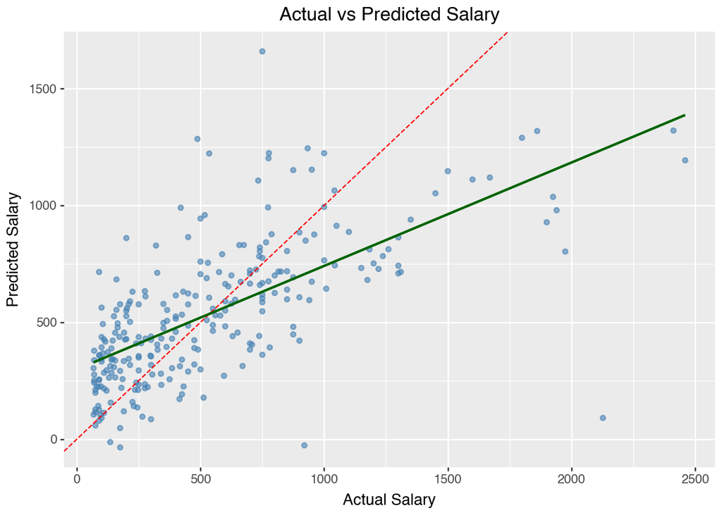

```python
from plotnine import *

df_plot = pd.DataFrame({
    'Actual': y,
    'Predicted': y_preds
})

(ggplot(df_plot, aes(x='Actual', y='Predicted'))
    + geom_point(alpha=0.6, color='steelblue')
    + geom_abline(intercept=0, slope=1, color='red', linetype='dashed')
    + geom_smooth(method='lm', color='darkgreen', se=False, size=1)
    + labs(
        title='Actual vs Predicted Salary',
        x='Actual Salary',
        y='Predicted Salary'
    ))
```